# Trabajo Final R

2025-02-06

tinytex::install_tinytex()

# **Procesamientos EPH-INDEC: Tercer trimestre de 2024**

Procesamientos de elaboración propia en base a la Encuesta Permantent de Hogares del Instituto Nacional de Estadisticas y Censos (Argentina). La EPH continua constituye el relevamiento socioeconómico de 31 aglomerados urbanos del país, donde habita, aproximadamente, el 70% de la población. Cubre todas las capitales de provincia y aglomerados urbanos de más de 100 mil habitantes. Tiene una periodicidad trimestral y se realizan 4 estimaciones por año de los principales indicadores del mercado de trabajo.

## **Población argentina en base a sexo**

En esta tabla se puede observar la composición total de la población relevada en base al sexo.

Población según Sexo

| Varones | Mujeres | Total |
| --- | --- | --- |
| 14.471.801 | 15.248.344 | 29.720.145 |

## **Población argentina en base a franja etaria**

En esta tabla se puede observar la composición total de la población relevada en base al segmento etario.

Nota: Los menores conforman a la población relevada desde el nacimiento hasta los 14 años inclusive, las juventudes abracan desde los 15 hasta los 29 años inclusive, los adultos desde los 30 años hasta los 64 años inclusive y los adultos mayores quienes tienen 65 años o más.

Población según franja etaria

| Menores | Juventudes | Adultos | Adultos Mayores | Total |
| --- | --- | --- | --- | --- |
| 6.688.406 | 6.658.495 | 12.688.249 | 3.684.995 | 29.720.145 |

## **Población argentina en base a nivel educativo**

Con el objeto de desentramar con mayor detalle las características de la población relevada por la EPH, en esta ocación se presenta la composición por el nivel educativo alcanzado.

Población según nivel educativo

| Menor a Secundaria | Secundaria Completa | Superior Completo | Total |
| --- | --- | --- | --- |
| 15.551.639 | 9.628.912 | 4.539.594 | 29.720.145 |

## Precariedad laboral

A continuación se aborda la precariedad laboral en el mercado de trabajo argentino, tomando como referencia a la población ocupada. Se consideran trabajadores en situación de precariedad a aquellos que se encuentran no registrados, en situación de inestabilidad (plan de empleo, beca o pasantía, periodo de prueba), trabajadores familiares sin remuneración y asalariados en establecimientos con menos de 5 empleados.

Cantidad de trabajadores ocupados en base a la situación de precariedad

| Trabajador en precariedad | Trabajador en no precariedad | Población ocupada |
| --- | --- | --- |
| 3.738.714 | 9.629.326 | 13.368.040 |

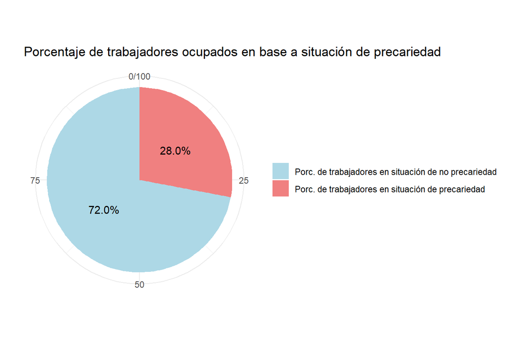

## Precariedad según sexo

Cantidad de trabajadores ocupados en base a la situación de precariedad

| Sexo | Trabajador en precariedad | Trabajador en no precariedad | Población ocupada |
| --- | --- | --- | --- |
| Hombre | 1.942.853 | 5.535.230 | 7.478.083 |
| Mujer | 1.795.861 | 4.094.096 | 5.889.957 |

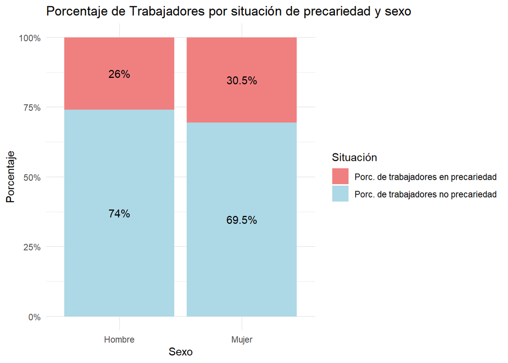

## Precariedad según franja etaria

Cantidad de trabajadores ocupados en base a la situación de precariedad y la franja etaria

| Franja Etaria | Trabajador en precariedad | Trabajador en no precariedad | Población ocupada |
| --- | --- | --- | --- |
| Adultos | 2.240.835 | 7.589.603 | 9.830.438 |
| Adultos Mayores | 118.621 | 468.969 | 587.590 |
| Jov.15-18 | 108.346 | 34.692 | 143.038 |
| Jov.19-24 | 699.646 | 550.774 | 1.250.420 |
| Jov.25-29 | 563.396 | 985.115 | 1.548.511 |
| Menores | 7.870 | 173 | 8.043 |

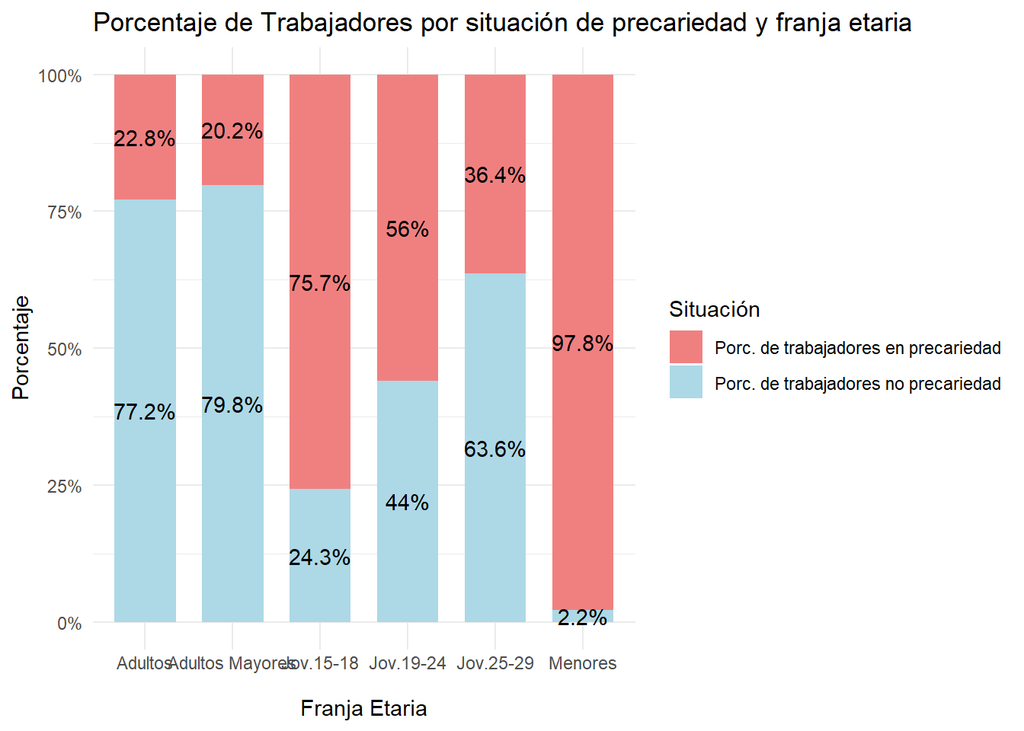

## Precariedad según nivel educativo

Cantidad de trabajadores ocupados en base a la situación de precariedad y el nivel educativo

| Nivel Educativo | Trabajador en precariedad | Trabajador en no precariedad | Población ocupada |
| --- | --- | --- | --- |
| Menor a Secundaria | 1.514.579 | 2.277.742 | 3.792.321 |
| Secundaria Completa | 1.768.492 | 4.259.158 | 6.027.650 |
| Superior Completo | 455.643 | 3.092.426 | 3.548.069 |

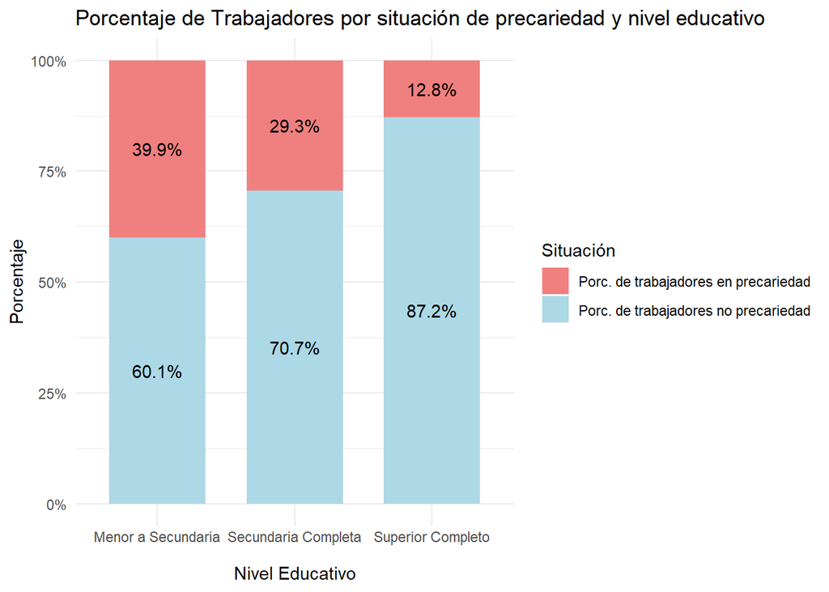